# Two Sigma Data Science Challenge - Section 1

Marcelo Rodrigues dos Santos

20 maio 2019

```r
library(dplyr)
library(ggplot2)
library(ggpubr)
library(reshape2)
```

```r
data_folder <- paste(getwd(), '/../datasets/', sep='')
```

## Stock Market Data

### Preparing data

Opening Dataset

```r
dfretorig <- read.csv(paste(data_folder,"returns_20181228.csv",sep=''), sep=',')
dfretorig$Date<-as.POSIXct(strptime(as.character(dfretorig$Date), "%Y-%m-%d"))
dfret<-dfretorig
```

First validation was checking if weeks were completed. There is at least one week with less than 5 days registered… but it could not be an issue.

```r
a<-filter(dfret,as.POSIXlt(Date)$wday==0|as.POSIXlt(Date)$wday==6)
nrow(dfret)/5
```

```
[1] 199.6
```

Analyzing the dataset I realized some stocks that only had positive returns during the studied period and higher average values. In this sense, when applying an accummulative approach to returns was causing an exponential effect. See this example.

```r
# stock_0
dfretaux <- dfret %>% select(Date, stock_0,stock_1,stock_10,stock_24,stock_265)%>%mutate(cum_stock_0=cumprod(1 + stock_0/100)-1)
dfretaux$Date<-as.POSIXct(strptime(as.character(dfretaux$Date), "%Y-%m-%d"))
# stock_1
dfretaux <- dfretaux %>% mutate(cum_stock_1=cumprod(1 + stock_1/100)-1)
# stock_10
dfretaux <- dfretaux %>% mutate(cum_stock_10=cumprod(1 + stock_10/100)-1)
# stock_24
dfretaux <- dfretaux %>% mutate(cum_stock_24=cumprod(1 + stock_24/100)-1)
# stock_265
dfretaux <- dfretaux %>% mutate(cum_stock_265=cumprod(1 + stock_265/100)-1)
```

See Stocks Cumulative Product graphs.

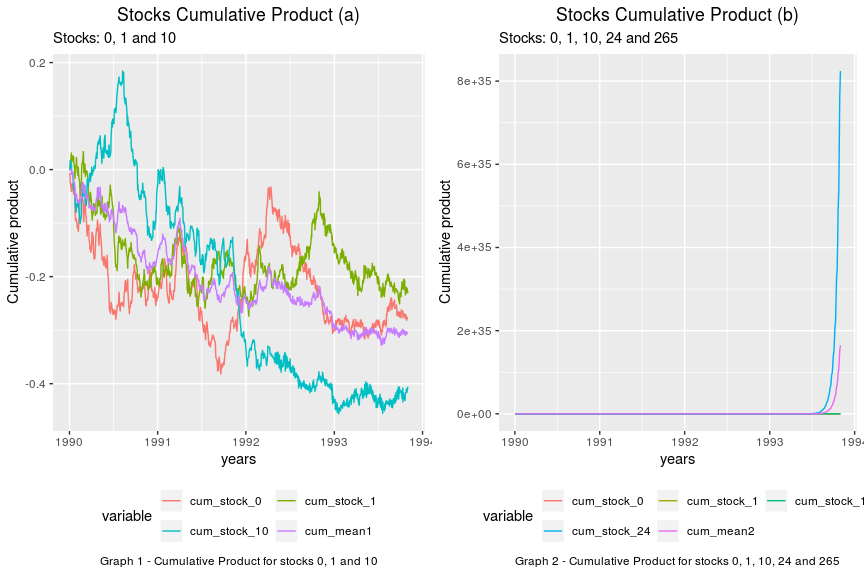

```r
dfretaux$cum_mean1<-(dfretaux$cum_stock_0+dfretaux$cum_stock_1+dfretaux$cum_stock_10)/3
a<-dfretaux[,c(1,7,8,9,12)]
dfretaux_a = melt(a, id=c("Date"))

p<-ggplot(dfretaux_a, aes(x=Date, y=value, colour=variable))+
  geom_line()+
  labs(
    title="Stocks Cumulative Product (a)", subtitle="Stocks: 0, 1 and 10", x="years", y = "Cumulative product", caption = "Graph 1 - Cumulative Product for stocks 0, 1 and 10") +
  theme(legend.position="bottom", plot.title = element_text(hjust = 0.5),
    plot.caption = element_text(hjust = 0.5))+
  guides(colour=guide_legend(nrow=2,byrow=TRUE))

dfretaux$cum_mean2<-(dfretaux$cum_stock_0+dfretaux$cum_stock_1+dfretaux$cum_stock_10+dfretaux$cum_stock_24+dfretaux$cum_stock_265)/5
a<-dfretaux[,c(1,7,8,9,10,13)]
dfretaux_a = melt(a, id=c("Date"))

q<-ggplot(dfretaux_a, aes(x=Date, y=value, colour=variable))+
  geom_line()+
  labs(
    title="Stocks Cumulative Product (b)", subtitle="Stocks: 0, 1, 10, 24 and 265", x="years", y = "Cumulative product", caption = "Graph 2 - Cumulative Product for stocks 0, 1, 10, 24 and 265") +
  theme(legend.position="bottom", plot.title = element_text(hjust = 0.5),
    plot.caption = element_text(hjust = 0.5))+
  guides(colour=guide_legend(nrow=2,byrow=TRUE))

ggarrange(p,q,ncol = 2, nrow = 1)
```

```r
dfret<-dfretorig
a<-data.frame()
qtde<-ncol(dfret)-1
for (i in 2:(qtde+1)) {
  a[i,'i']<-ifelse(min(dfret[,i],na.rm=TRUE)>=0,i,-1)
  a[i,'name']<-colnames(dfret)[i]
  a[i,'mean']<-mean(dfret[,i],na.rm=TRUE)
  a[i,'sd']<-sd(dfret[,i],na.rm=TRUE)
  a[i,'max']<-max(dfret[,i],na.rm=TRUE)
}
aa<-filter(a,i>=0)
head(aa)
```

|  | i | name | mean | sd | max |
| --- | --- | --- | --- | --- | --- |
| 1 | 26 | stock_24 | 8.646928 | 1.2672130 | 13.397187 |
| 2 | 28 | stock_26 | 7.605875 | 1.3603949 | 11.869122 |
| 3 | 46 | stock_44 | 7.720910 | 0.9748104 | 10.570228 |
| 4 | 49 | stock_47 | 7.840140 | 1.2234774 | 12.538382 |
| 5 | 50 | stock_48 | 6.353033 | 0.9394883 | 9.705307 |
| 6 | 51 | stock_49 | 7.176961 | 1.0569560 | 11.193172 |

As it is clearly a mistake… these columns (stocks) must be removed…

```r
dfret<-dfret[,-c(aa$i)]
```

Plotting the daily return average without NAs and stocks with exponential behavior.

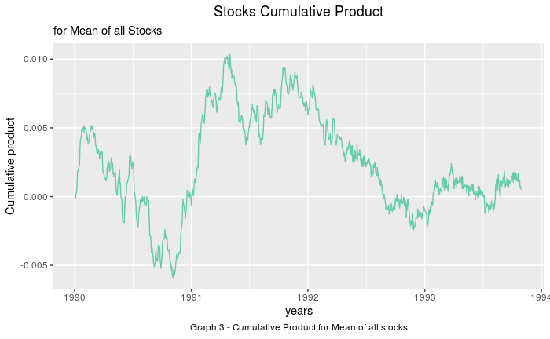

```r
qtde<-ncol(dfret)-1
dfretnew <- dfret[,2:(qtde+1)]/100
dfretnew$media <- dfretnew[,1:qtde]%>%rowSums(na.rm=TRUE)
dfretnew$media <- dfretnew$media/qtde
dfretnew <- dfretnew %>% mutate(acumout=cumprod(1 + media)-1,acumoutsig1=lag(acumout,1))
dfretnew$Date <- dfret$Date

ggplot(dfretnew, aes(x=Date)) +
  geom_line(aes(y=acumout),colour = 'aquamarine3',na.rm=TRUE) +
  labs(
    title="Stocks Cumulative Product", subtitle="for Mean of all Stocks", x="years", y = "Cumulative product", caption = "Graph 3 - Cumulative Product for Mean of all stocks") +
  theme(legend.position="bottom", plot.title = element_text(hjust = 0.5),
    plot.caption = element_text(hjust = 0.5))+
  guides(colour=guide_legend(nrow=2,byrow=TRUE))
```

## ———

### Question #1:

In what month did the returns shift from exhibiting mean reversion to exhibiting momentum, or from exhibiting momentum to exhibiting mean reversion?

Generating autocorrelation probabilities for all stocks.

```r
c<-data.frame()
qtde<-nrow(dfretnew)
for (i in nrow(dfretnew):101) {
  c[i,'acf']<-acf(dfretnew$media[(i-100):i],type='correlation',lag.max=1, plot=FALSE)$acf[2]
  c[i,'dt']<-as.POSIXct(dfretnew[i,'Date'])
  c[i,'signal']<-ifelse(c[i,'acf']>=0,1,-1)
  c[i,'media']<-dfretnew[i,'media']
}
```

Plotting daily autocorrelations

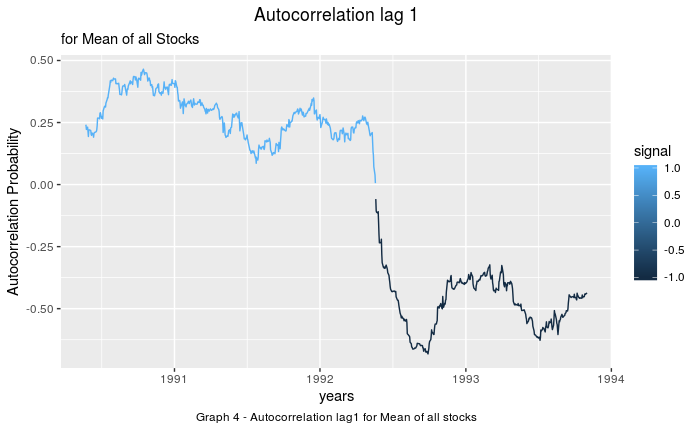

```r
ggplot(c, aes(x=dt, group=signal, colour = signal)) +
  geom_line(aes(y=acf), na.rm=TRUE) +
    labs(title="Autocorrelation lag 1", subtitle="for Mean of all Stocks", x="years", y = "Autocorrelation Probability",caption = "Graph 4 - Autocorrelation lag1 for Mean of all stocks") +
  theme(plot.title = element_text(hjust = 0.5),
    plot.caption = element_text(hjust = 0.5))
```

Autocorrelation starts to be negative on May 20th, 1992.

```r
c[615:625,]
```

|  | acf | dt | signal | media |
| --- | --- | --- | --- | --- |
| 615 | 0.134639803 | 1992-05-13 | 1 | 5.836178e-04 |
| 616 | 0.118097756 | 1992-05-14 | 1 | -7.117023e-04 |
| 617 | 0.071969403 | 1992-05-15 | 1 | 5.962736e-04 |
| 618 | 0.038805324 | 1992-05-18 | 1 | -6.401806e-04 |
| 619 | 0.005775481 | 1992-05-19 | 1 | 7.072880e-04 |
| 620 | -0.058420835 | 1992-05-20 | -1 | -1.204117e-03 |
| 621 | -0.106265078 | 1992-05-21 | -1 | 5.278600e-04 |
| 622 | -0.111425612 | 1992-05-22 | -1 | -4.224977e-04 |
| 623 | -0.115077757 | 1992-05-25 | -1 | -9.733431e-06 |
| 624 | -0.109137687 | 1992-05-26 | -1 | 8.086162e-04 |

[output cut: 1 more lines]

**Answer for question #1 is May 1992**

### Question #2:

What was the average momentum? Single number: the average across all stock returns in the time period.

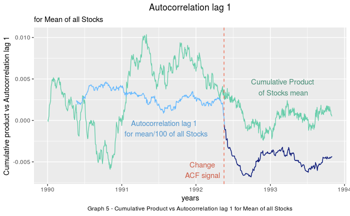

```r
ggplot(dfretnew, aes(x=Date)) +
  geom_line(aes(y=acumout),colour = 'aquamarine3',na.rm=TRUE) +
  geom_line(aes(y=c$acf/100),colour = 'steelblue1') +
  geom_line(aes(y=c(rep_len(NA,619),c$acf[620:998]/100)),colour = 'midnightblue') +
  geom_vline(xintercept = as.POSIXct('1992-05-18'), colour='coral2',linetype = "dashed")+
  labs(title="Autocorrelation lag 1", subtitle="for Mean of all Stocks", x="years", y = "Cumulative product vs Autocorrelation lag 1", caption = "Graph 5 - Cumulative Product vs Autocorrelation lag 1 for Mean of all Stocks") +
  theme(plot.title = element_text(hjust = 0.5),
    plot.caption = element_text(hjust = 0.5))+
  annotate("text", x = as.POSIXct("1991-08-01"), y = -0.001, label = "Autocorrelation lag 1 \n for mean/100 of all Stocks", colour = "steelblue3")+
  annotate("text", x = as.POSIXct("1993-03-01"), y = 0.004, label = "Cumulative Product\n of Stocks mean", colour = "aquamarine4")+
  annotate("text", x = as.POSIXct("1992-02-01"), y = -0.006, label = "Change\nACF signal", colour = "coral3")
```

**Answer for Question #2: 6.048072210^{-4}**

### Question #3:

What was the average mean reversion? Average during the time period when these stock returns exhibited mean reversion.

```r
reversion<-subset(dfretnew,format(Date,"%Y-%m-%d")>'1992-05-19')
```

**Answer for Question #3: is -8.322922710^{-4}**

### Question #4:

Why might the market shift from momentum being dominant to mean reversion being dominant (or the other way around)?

**Answer #4: for example, if this analyzed market was a young market and then it became mature the effect of the shifting from momentum to mean reversion dominant could have happened.**

### Question #5:

Why might trading momentum or mean reversion succeed as a strategy? Why might it fail?

**Answer #5: As we saw in Graph 5, the momentum strategy is more related to following a trend, and the mean reversion strategy means that the stock returns dynamics happen around the mean. If you are able to observe the behavior of a stock or set of assets over a certain period of time, both strategies can succeed from a mathematical and statistical point of view. However, sometimes the market may also behave differently due to unfamiliar external events and break the expected behavior or results.**